## Albina Jetybayeva. DSE511. Project 1.

# Task 4. Analyze the effect of major holidays on Covid cases

The analysis of the impact of holidays on the confirmed new covid cases in different countries will be done, where 2 countries are chosen: the USA and Kazakhstan. The cases will be calculated as the aggregated number of new cases over 2 weeks before and 2 weeks after the actual holiday. These numbers will be compared. The holidays will be chosen as follows.

The USA's major holidays:

- Thanksgiving [November 26]
- Independence Day [July 4]
- Christmas [December 25]

Kazakhstan's major holidays:

- New Year [January 1]
- Nauryz (Nomadic New Year) [March 22]
- Unity Day [May 1]

The covid cases of both countries will be compared to these major holidays. As the cases are accumulated in the data file, the total new cases over the 2 weeks period will be calculated as follows:

[New cases for the period BEFORE the holiday] = [Confirmed cases on the holiday] - [Confirmed cases on a day 2 weeks before the holiday]

Similarly for after the holiday period:

[New cases for the period AFTER the holiday] = [Confirmed cases on a day 2 weeks after the holiday] - [Confirmed cases on the holiday]

```python
#First load the necessary packages:

import pandas as pd
import numpy as np
import matplotlib as mpl
import matplotlib.pyplot as plt
```

```python
#Extract the main data file for the confirmed cases:

data = pd.read_csv('time_series_covid19_confirmed_global.csv')
print(data)
data.head()
```

```
    Province/State      Country/Region        Lat        Long  1/22/20  \
0              NaN         Afghanistan  33.939110   67.709953        0
1              NaN             Albania  41.153300   20.168300        0
2              NaN             Algeria  28.033900    1.659600        0
3              NaN             Andorra  42.506300    1.521800        0
4              NaN              Angola -11.202700   17.873900        0
..             ...                 ...        ...         ...      ...
274            NaN             Vietnam  14.058324  108.277199        0
275            NaN  West Bank and Gaza  31.952200   35.233200        0
276            NaN               Yemen  15.552727   48.516388        0
277            NaN              Zambia -13.133897   27.849332        0
278            NaN            Zimbabwe -19.015438   29.154857        0

     1/23/20  1/24/20  1/25/20  1/26/20  1/27/20  ...  8/29/21  8/30/21  \
0          0        0        0        0        0  ...   152960   153148
```

[output cut: 25 more lines]

|  | Province/State | Country/Region | Lat | Long | 1/22/20 | 1/23/20 | 1/24/20 | 1/25/20 | 1/26/20 | 1/27/20 | ... | 8/29/21 | 8/30/21 | 8/31/21 | 9/1/21 | 9/2/21 | 9/3/21 | 9/4/21 | 9/5/21 | 9/6/21 | 9/7/21 |
| --- | --- | --- | --- | --- | --- | --- | --- | --- | --- | --- | --- | --- | --- | --- | --- | --- | --- | --- | --- | --- | --- |
| 0 | NaN | Afghanistan | 33.93911 | 67.709953 | 0 | 0 | 0 | 0 | 0 | 0 | ... | 152960 | 153148 | 153220 | 153260 | 153306 | 153375 | 153375 | 153375 | 153534 | 153626 |
| 1 | NaN | Albania | 41.15330 | 20.168300 | 0 | 0 | 0 | 0 | 0 | 0 | ... | 144847 | 145333 | 146387 | 147369 | 148222 | 149117 | 150101 | 150997 | 151499 | 152239 |
| 2 | NaN | Algeria | 28.03390 | 1.659600 | 0 | 0 | 0 | 0 | 0 | 0 | ... | 195162 | 195574 | 196080 | 196527 | 196915 | 197308 | 197659 | 198004 | 198313 | 198645 |
| 3 | NaN | Andorra | 42.50630 | 1.521800 | 0 | 0 | 0 | 0 | 0 | 0 | ... | 15025 | 15032 | 15033 | 15046 | 15052 | 15055 | 15055 | 15055 | 15069 | 15070 |
| 4 | NaN | Angola | -11.20270 | 17.873900 | 0 | 0 | 0 | 0 | 0 | 0 | ... | 47168 | 47331 | 47544 | 47781 | 48004 | 48261 | 48475 | 48656 | 48790 | 49114 |

5 rows × 599 columns

## Part 1. The USA's major holidays. Thanksgiving.

```python
#Extract data from the file for the USA Thanksgiving holiday date:

data1 = data.set_index("Country/Region", drop = False)
th1_usa=data1.loc["US", "11/26/20"]
print(th1_usa)
```

```
13006455
```

```python
#Extract data from the file for the USA 2 weeks before Thanksgiving holiday date:

th2_usa=data1.loc["US", "11/12/20"]
print(th2_usa)
```

```
10660154
```

```python
#Find the total new cases for the period of 2 weeks before holiday:

th_usa_b=th1_usa-th2_usa
print(th_usa_b)
```

```
2346301
```

```python
#Extract data from the file for the USA 2 weeks after Thanksgiving holiday date:

th3_usa=data1.loc["US", "12/11/20"]
print(th3_usa)
```

```
16028086
```

```python
#Find the total new cases for the period of 2 weeks after holiday:

th_usa_af=th3_usa-th1_usa
print(th_usa_af)
```

```
3021631
```

```python
#The same procedure for Kazakhstan (Just to compare and contrast two countries later)

th1_kz=data1.loc["Kazakhstan", "11/26/20"]
print(th1_kz)
th2_kz=data1.loc["Kazakhstan", "11/12/20"]
print(th2_kz)
th_kz_b=th1_kz-th2_kz
print(th_kz_b)
th3_kz=data1.loc["Kazakhstan", "12/11/20"]
print(th3_kz)
th_kz_af=th3_kz-th1_kz
print(th_kz_af)
```

```
170808
158036
12772
184557
13749
```

# Part 2. Independence Day. 4th July.

```python
# Use the same file and extract the data for the USA and Independence Day dates:

ju1_usa=data1.loc["US", "7/4/21"]
print(ju1_usa)
ju2_usa=data1.loc["US", "6/19/21"]
print(ju2_usa)
ju_usa_b=ju1_usa-ju2_usa
print(ju_usa_b)
ju3_usa=data1.loc["US", "7/18/21"]
print(ju3_usa)
ju_usa_af=ju3_usa-ju1_usa
print(ju_usa_af)
```

```
33717782
33538065
179717
34079990
362208
```

```python
# Repeat for Kazakhstan and Independence Day dates:

ju1_kz=data1.loc["Kazakhstan", "7/4/21"]
print(ju1_kz)
ju2_kz=data1.loc["Kazakhstan", "6/19/21"]
print(ju2_kz)
ju_kz_b=ju1_kz-ju2_kz
print(ju_kz_b)
ju3_kz=data1.loc["Kazakhstan", "7/18/21"]
print(ju3_kz)
ju_kz_af=ju3_kz-ju1_kz
print(ju_kz_af)
```

```
491277
464010
27267
547510
56233
```

# Part 3. Christmas.

```python
# Use the same file and extract the data for the USA and Christmas dates:

ch1_usa=data1.loc["US", "12/25/20"]
print(ch1_usa)
ch2_usa=data1.loc["US", "12/11/20"]
print(ch2_usa)
ch_usa_b=ch1_usa-ch2_usa
print(ch_usa_b)
ch3_usa=data1.loc["US", "1/8/21"]
print(ch3_usa)
ch_usa_af=ch3_usa-ch1_usa
print(ch_usa_af)
```

```
18874122
16028086
2846036
22011753
3137631
```

```python
# Repeat for Kazakhstan and Chrsitmas dates:

ch1_kz=data1.loc["Kazakhstan", "12/25/20"]
print(ch1_kz)
ch2_kz=data1.loc["Kazakhstan", "12/11/20"]
print(ch2_kz)
ch_kz_b=ch1_kz-ch2_kz
print(ch_kz_b)
ch3_kz=data1.loc["Kazakhstan", "1/8/21"]
print(ch3_kz)
ch_kz_af=ch3_kz-ch1_kz
print(ch_kz_af)
```

```
196216
184557
11659
207683
11467
```

# Part 4. Kazakhstan's major holidays. New Year.

```python
# Use the same file and extract the data for the KZ and New Year dates:

ny1_kz=data1.loc["Kazakhstan", "1/1/21"]
print(ny1_kz)
ny2_kz=data1.loc["Kazakhstan", "12/18/20"]
print(ny2_kz)
ny_kz_b=ny1_kz-ny2_kz
print(ny_kz_b)
ny3_kz=data1.loc["Kazakhstan", "1/15/21"]
print(ny3_kz)
ny_kz_af=ny3_kz-ny1_kz
print(ny_kz_af)
```

```
202060
190292
11768
213855
11795
```

```python
# Repeat for the USA and New Year dates:

ny1_usa=data1.loc["US", "1/1/21"]
print(ny1_usa)
ny2_usa=data1.loc["US", "12/18/20"]
print(ny2_usa)
ny_usa_b=ny1_usa-ny2_usa
print(ny_usa_b)
ny3_usa=data1.loc["US", "1/15/21"]
print(ny3_usa)
ny_usa_af=ny3_usa-ny1_usa
print(ny_usa_af)
```

```
20254160
17575546
2678614
23636699
3382539
```

# Part 5. Nauryz holiday

```python
# Use the same file and extract the data for the KZ and Nauryz dates:

n1_kz=data1.loc["Kazakhstan", "3/22/21"]
print(n1_kz)
n2_kz=data1.loc["Kazakhstan", "3/8/21"]
print(n2_kz)
n_kz_b=n1_kz-n2_kz
print(n_kz_b)
n3_kz=data1.loc["Kazakhstan", "4/5/21"]
print(n3_kz)
n_kz_af=n3_kz-n1_kz
print(n_kz_af)
```

```
284138
268902
15236
307676
23538
```

```python
# Repeat for the USA and Nauryz dates:

n1_usa=data1.loc["US", "3/22/21"]
print(n1_usa)
n2_usa=data1.loc["US", "3/8/21"]
print(n2_usa)
n_usa_b=n1_usa-n2_usa
print(n_usa_b)
n3_usa=data1.loc["US", "4/5/21"]
print(n3_usa)
n_usa_af=n3_usa-n1_usa
print(n_usa_af)
```

```
29876125
29112547
763578
30789920
913795
```

# Part 6. Unity Day. May 1.

```python
# Use the same file and extract the data for the KZ and Unity Day dates:

m1_kz=data1.loc["Kazakhstan", "5/1/21"]
print(m1_kz)
m2_kz=data1.loc["Kazakhstan", "4/17/21"]
print(m2_kz)
m_kz_b=m1_kz-m2_kz
print(m_kz_b)
m3_kz=data1.loc["Kazakhstan", "5/15/21"]
print(m3_kz)
m_kz_af=m3_kz-m1_kz
print(m_kz_af)
```

```
378441
338764
39677
412236
33795
```

```python
# Repeat for the USA and Unity Day dates:

m1_usa=data1.loc["US", "5/1/21"]
print(m1_usa)
m2_usa=data1.loc["US", "4/17/21"]
print(m2_usa)
m_usa_b=m1_usa-m2_usa
print(m_usa_b)
m3_usa=data1.loc["US", "5/15/21"]
print(m3_usa)
m_usa_af=m3_usa-m1_usa
print(m_usa_af)
```

```
32396265
31631770
764495
32927841
531576
```

```python
# Create a list of the USA data (before)

usa_before = [th_usa_b, ju_usa_b, ch_usa_b, ny_usa_b, n_usa_b, m_usa_b]
print(usa_before)
```

```
[2346301, 179717, 2846036, 2678614, 763578, 764495]
```

```python
# Create a list of the USA data (after)

usa_after = [th_usa_af, ju_usa_af, ch_usa_af, ny_usa_af, n_usa_af, m_usa_af]
print(usa_after)
```

```
[3021631, 362208, 3137631, 3382539, 913795, 531576]
```

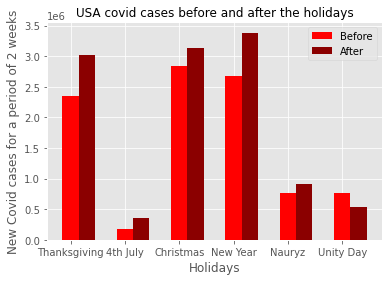

```python
# Plot and observe the features of the USA case:

mpl.style.use(['ggplot']) #use ggplot style
x = ['Thanksgiving', '4th July', 'Christmas', 'New Year', 'Nauryz', 'Unity Day']
x_pos = [i for i, _ in enumerate(x)]
width = 0.3

plt.bar(np.arange(len(usa_before)), usa_before, width=width, color='red', label='Before')
plt.bar(np.arange(len(usa_after))+ width, usa_after, width=width, color='darkred', label='After')

plt.xlabel("Holidays")
plt.ylabel("New Covid cases for a period of 2 weeks")
plt.title("USA covid cases before and after the holidays", fontsize=12)
plt.legend(loc='best')


plt.xticks(x_pos, x)
plt.show()
```

```python
# Create a list of the Kazakhstan data (before)

kz_before = [th_kz_b, ju_kz_b, ch_kz_b, ny_kz_b, n_kz_b, m_kz_b]
print(kz_before)
```

```
[12772, 27267, 11659, 11768, 15236, 39677]
```

```python
# Create a list of the Kazakhstan data (after)

kz_after = [th_kz_af, ju_kz_af, ch_kz_af, ny_kz_af, n_kz_af, m_kz_af]
print(kz_after)
```

```
[13749, 56233, 11467, 11795, 23538, 33795]
```

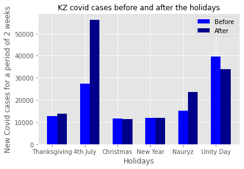

```python
# Plot and observe the features of the Kazakhstan case:

x = ['Thanksgiving', '4th July', 'Christmas', 'New Year', 'Nauryz', 'Unity Day']
x_pos = [i for i, _ in enumerate(x)]
width = 0.3

plt.bar(np.arange(len(kz_before)), kz_before, width=width, color='blue', label='Before')
plt.bar(np.arange(len(kz_after))+ width, kz_after, width=width, color='darkblue', label='After')


plt.xlabel("Holidays")
plt.ylabel("New Covid cases for a period of 2 weeks")
plt.title("KZ covid cases before and after the holidays", fontsize=12)
plt.legend(loc='best')


plt.xticks(x_pos, x)
plt.show()
```

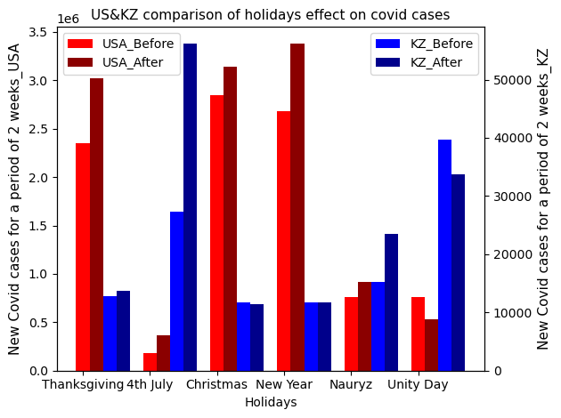

```python
# Plot both countries to compare with each other:

mpl.style.use(['default']) #use ggplot style

width = 0.3


idx = np.arange(len(usa_before))-0.3

fig, ax7 = plt.subplots()
ax7.bar(idx, usa_before, width=0.2, color='red', label='USA_Before')
ax7.bar(idx+0.2, usa_after, width=0.2, color='darkred', label ='USA_After')



ax8 = ax7.twinx()  # instantiate a second axes that shares the same x-axis
ax8.bar(idx + 0.4, kz_before, width=0.2, color='blue', label='KZ_Before')
ax8.bar(idx + 0.6, kz_after, width=0.2, color='darkblue', label ='KZ_After')


ax7.set_ylabel('New Covid cases for a period of 2 weeks_USA', fontsize=11)
ax7.set_xlabel('Holidays')
ax7.set_title('US&KZ comparison of holidays effect on covid cases', fontsize=11)
ax7.set_xticks(idx)
ax7.set_xticklabels(('Thanksgiving', '4th July', 'Christmas', 'New Year', 'Nauryz', 'Unity Day'))
ax7.legend(loc=2)
ax8.legend(loc=1)
ax8.set_ylabel('New Covid cases for a period of 2 weeks_KZ', fontsize=11)

fig.tight_layout()
plt.show()
```

```python
#Used this to play around with the styles of plots
print(plt.style.available)
```

```
['Solarize_Light2', '_classic_test_patch', 'bmh', 'classic', 'dark_background', 'fast', 'fivethirtyeight', 'ggplot', 'grayscale', 'seaborn', 'seaborn-bright', 'seaborn-colorblind', 'seaborn-dark', 'seaborn-dark-palette', 'seaborn-darkgrid', 'seaborn-deep', 'seaborn-muted', 'seaborn-notebook', 'seabo…
```

# Summary

### For the USA

- The certain increase in the new covid cases was observed after all major USA holidays: Thanksgiving, 4th of July, and Christmas. This confirms the expectation of the wider spread of the virus with holidays, as more people travel and have gatherings at that time.
- It could be also seen that for the USA's New Year holiday the cases have risen and this can be attributed to the fact that Christmas and New Year are very close to each other and people have long holidays at this period, which results in more travels again and higher chances of spreading the virus.
- Interestingly, the small growth of covid cases was observed in the period of Kazakh holiday Nauryz, which coincidence with a spring break period for the USA (March 9-April 21). And as it is known again travels are increased within the free time of people and parents take their families for trips. Thus, probably such a trend was shown.
- The Unity day, being an unrelated holiday to the USA did not demonstrate and cases growth.

### For Kazakhstan

- The trends are less consistent due to other factors.
- Among all major national holidays only Nauryz showed the larger number of cases for the "after holiday" period. That might have happened because Kazakhsanis had the weekend on March 20-21, then official off days for March 22-24, a small gap of 2 working days, and then the weekend again. So many people traveled around that quite long period, by taking their own days off for the 2 gap working days and having around 10 days in total. That might have caused the increase of virus spread.
- In contrast, the Unity Day was on Saturday so people had only 1 extra day of holiday on Monday so not many of them had trips.
- New Year and Christmas did not show increased value for new covid cases, since at that period stricter lockdown rules have been implemented. Also, the weather was very cold and snowy, so transportation was limited at that time.
- For thanksgiving not much big difference in cases was detected, as it is not a holiday for Kazakhstan and people do not celebrate it.
- Interestingly, more than the double increase of the cases was seen in the period of 4th of July. That is mainly due to the long summer vacation period in Kazakhstan for school and university students. So many families have trips and gatherings during that period. Summer is also the best time to travel since in winter, spring, and fall weather is mostly not favorable. Thus, in Kazakhstan in general, the largest covid waves happened in summers 2020 and 2021.

### Overall

Comparing the USA and Kazakhstan obviously the number of cases is much smaller for Kazakhstan, as the population and density are significantly lower.

## Reference

https://www.nature.com/articles/d41586-020-03545-1

https://www.cidrap.umn.edu/news-perspective/2021/07/states-report-increase-covid-19-cases-over-holiday

https://www.cnn.com/2020/12/26/health/us-coronavirus-saturday/index.html

https://www.usatoday.com/story/travel/news/2021/03/22/spring-break-2021-travel-millions-board-flights-amid-covid-pandemic/4796301001/

https://abcnews.go.com/Health/potential-post-holiday-covid-19-surge-catastrophic-impact/story?id=74859998